# Exploring NYPD activity from 2009 - 2016

Geospatial Visualizations

Natasha Mathur

```r
ncm_colors <- c("#C732D5", "#8AC437", "#F65D3A","#4369EB", "#32D59B", "#EDA03C")
ncm_colors_names <- c('Purple', 'Green', 'Orange', 'Blue', 'Teal', 'Yellow')
ncm_colors_wgrey <- c("#C732D5", "#8AC437", "#F65D3A","#4369EB", "#32D59B", "#EDA03C", "#F4F4F4")
ncm_colors_scaled <- c("#C732D5", "#F65D3A",  "#EDA03C", "#32D59B","#8AC437", "#4369EB")
ncm_highlight <-c("#C732D5")
ncm_contrast <- c("#F4F4F4")
ncm_map_gradient <- c(low="#EFEDF5", mid="#C576D5", high=ncm_highlight)
ncm_font <- "Helvetica"
ncm_theme <- theme(panel.grid.major = element_blank(), panel.grid.minor = element_blank(),
        plot.title = element_text(hjust = 0.5, face = "bold"),
        plot.subtitle = element_text(hjust=0.5), panel.background = element_rect(fill = "white"),
        legend.position="none", text=element_text(family=ncm_font))
ann_specs <- c(family=ncm_font, fontface=2, color="white")
gl_specs <- c(color="white", linetype="dashed")
```

### Stop, Question, and Frisk

Stop and Frisk is a NYPD policy that was mainly started under Police Commissioner William Bratton. It was based on an idea introduced in the 1982 “broken windows” paper by social scientists James Q. Wilson and George L. Kelling. Their analysis suggested that cracking down on small crimes like vandalism would help reduce the occurence of more serious ones. The policy allows police officers to stop, question, and search people without a warrant or suspicion of a crime.

The number of stops peaked in 2011, along with public outrage about the practice. The policy was heavily criticized for the high amount of force used, the lack of evidence that it improved safety, and most importantly, the fact that most of the people stopped were black or hispanic. Neither the Mayor or Police Commissioner provided an adequate explanation for any of those issues.

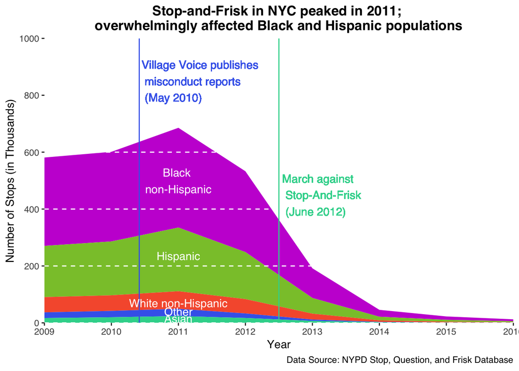

```r
p <- ggplot(yr, aes(x = year, y=pct, , fill = race_w_hisp.ord))
p + geom_area()  + scale_fill_manual(values=ncm_colors[-6])+
  xlab("Year") + ylab("Number of Stops (in Thousands)") +
  scale_x_continuous(breaks=seq(2009,2017,1), expand = c(0.00,0.00)) +
   theme(panel.grid.major = element_blank(), panel.grid.minor = element_blank(),
        plot.title = element_text(hjust = 0.5, face = "bold"),
        plot.subtitle = element_text(hjust=0.5), panel.background = element_rect(fill = "white"),
        legend.position="none", text=element_text(family=ncm_font)) +
  scale_y_continuous(expand=c(0,0), breaks=seq(0, 1000, 200)) + expand_limits(y = c(0, 1000)) +
  labs(title= "Stop-and-Frisk in NYC peaked in 2011; \noverwhelmingly affected Black and Hispanic populations") +
  labs(caption="Data Source: NYPD Stop, Question, and Frisk Database") +
  geom_vline(xintercept=2010.416, color="#4369EB", linetype="solid") +
  geom_vline(xintercept=2012.5, colour="#32D59B", linetype="solid") +
  annotate("text", x = 2011, y = 500, label = "Black \nnon-Hispanic", family=ncm_font, fontface=1, color="white") +
  annotate("text", x = 2011, y = 235, label = "Hispanic", family=ncm_font, fontface=1, color="white") +
  annotate("text", x = 2011, y = 70, label = "White non-Hispanic", family=ncm_font, fontface=1, color="white") +
  annotate("text", x = 2011, y = 40, label = "Other", family=ncm_font, fontface=1, color="white") +
  annotate("text", x = 2011, y = 15, label = "Asian", family=ncm_font, fontface=1, color="white") +
  geom_hline(yintercept=seq(0, 600, by=200), colour="white", linetype="dashed") +
  geom_text(aes(x= 2012.55, y = 450, hjust = 0, label="March against \n Stop-And-Frisk \n (June 2012)"),  color="#32D59B", family=ncm_font, fontface=1) +
  geom_text(aes(x=2010.45, y = 850, hjust=0, label="Village Voice publishes \n misconduct reports \n (May 2010)"), color="#4369EB", family=ncm_font, fontface=1)
```

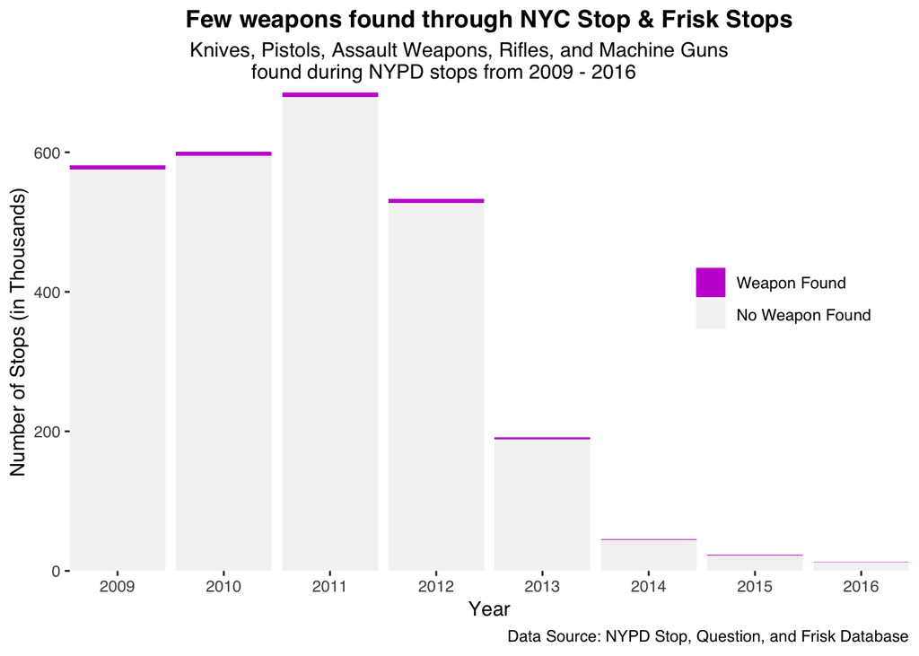

```r
ww <- ggplot(wf, aes(fill = forcats::fct_rev(weapon_found), y=num_stops, x=year))  + geom_bar(stat="identity") + xlab("Year") + ylab("Number of Stops (in Thousands)") +
  theme(panel.grid.major = element_blank(), panel.grid.minor = element_blank(),
    plot.title = element_text(hjust = 0.5, face="bold"), panel.background = element_rect(fill = "white"), plot.subtitle = element_text(hjust=0.4), legend.position =c(0.85, 0.6), text=element_text(family=ncm_font)) +
  scale_x_continuous(breaks=seq(2009,2017,1), expand = c(0,0)) +
  scale_y_continuous(breaks=seq(0,600,200), expand = c(0,0))  +
  scale_fill_manual(values=c(ncm_highlight, ncm_contrast),
    name="",
    breaks=c("Y", "N"),
    labels=c("Weapon Found", "No Weapon Found")) +
 labs(title="Few weapons found through NYC Stop & Frisk Stops",
   subtitle="Knives, Pistols, Assault Weapons, Rifles, and Machine Guns\nfound during NYPD stops from 2009 - 2016", caption="Data Source: NYPD Stop, Question, and Frisk Database")
ww
```

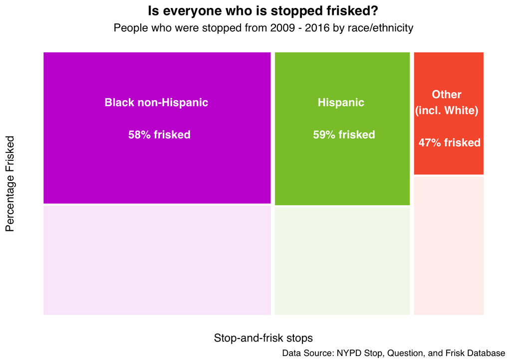

```r
f <- ggplot(data = fr2)
f +
  geom_mosaic(aes(product(race_w_hisp), fill=race_w_hisp,alpha=frisked), na.rm=TRUE) +
  theme(legend.position="none",plot.title = element_text(hjust = 0.5, face="bold"),
        plot.subtitle=element_text(hjust=0.5), axis.text = element_blank(),
        panel.background = element_rect(fill = "white"), axis.ticks = element_line(color = "white"),
        text=element_text(family=ncm_font)) + scale_fill_manual(values=ncm_colors[0:3]) +
  xlab('Stop-and-frisk stops') + ylab("Percentage Frisked") +
  labs(title="Is everyone who is stopped frisked?",
       subtitle="People who were stopped from 2009 - 2016 by race/ethnicity",
       caption="Data Source: NYPD Stop, Question, and Frisk Database") +
  annotate("text", x = .26, y = .75, label = "Black non-Hispanic \n\n 58% frisked",family=ncm_font, fontface=2, color="white") +
  annotate("text", x = .68, y = .75, label = "Hispanic \n\n 59% frisked", family=ncm_font, fontface=2, color="white") +
  annotate("text", x = .92, y = .75, label = "Other \n(incl. White) \n\n 47% frisked", family=ncm_font, fontface=2, color="white")
```

#### Accompanying Maps

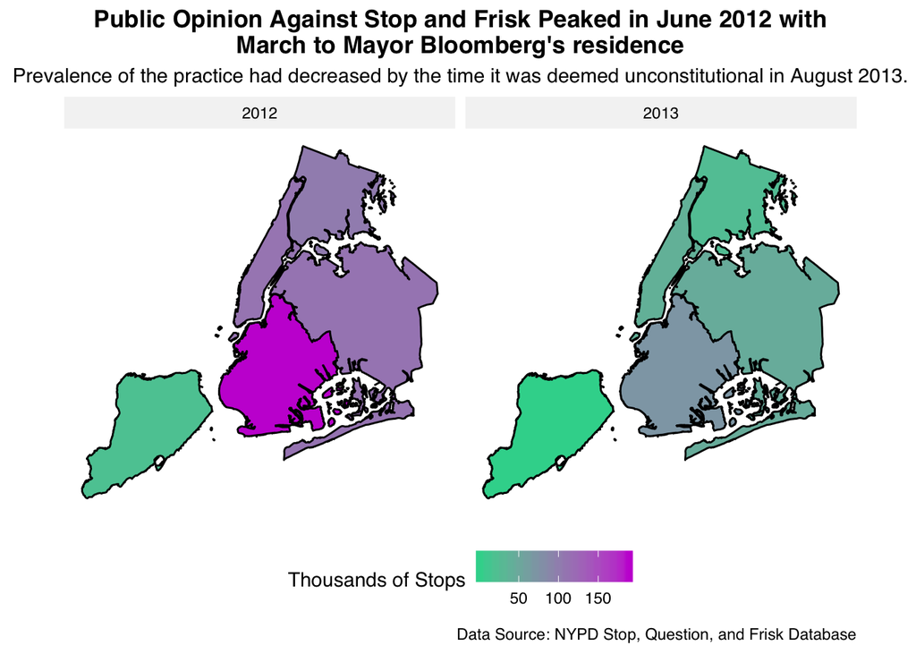

```r
ggplot(data = bdf) + facet_wrap(~year) +
    geom_sf(color="black", aes(fill = num_stops)) + scale_fill_gradient(low="#32D59B", high=ncm_highlight, name="Thousands of Stops") +
  theme(panel.grid.major = element_line(colour = "white"), panel.grid.minor = element_blank(),
        plot.title = element_text(hjust = 0.5, face = "bold"),
        plot.subtitle = element_text(hjust=0.5), panel.background = element_rect(fill = "white"),
        text=element_text(family=ncm_font), strip.background = element_rect(fill=ncm_contrast), strip.text = element_text(color="black"), axis.text = element_blank(),
        axis.ticks =element_blank(), legend.position = "bottom") +
  labs(title="Public Opinion Against Stop and Frisk Peaked in June 2012 with\nMarch to Mayor Bloomberg's residence",
       subtitle = "Prevalence of the practice had decreased by the time it was deemed unconstitutional in August 2013.",
       caption="Data Source: NYPD Stop, Question, and Frisk Database")
```

New York City is a diverse city, and about 25% of the population is black. However, throughout all boroughs the proportion of black detainees far surpassed the corresponding percentage of the population. The following two maps focus on the height of stop and frisk in 2011 and show this discrepancy; one for Manhattan and Brooklyn and one for the other three boroughs.

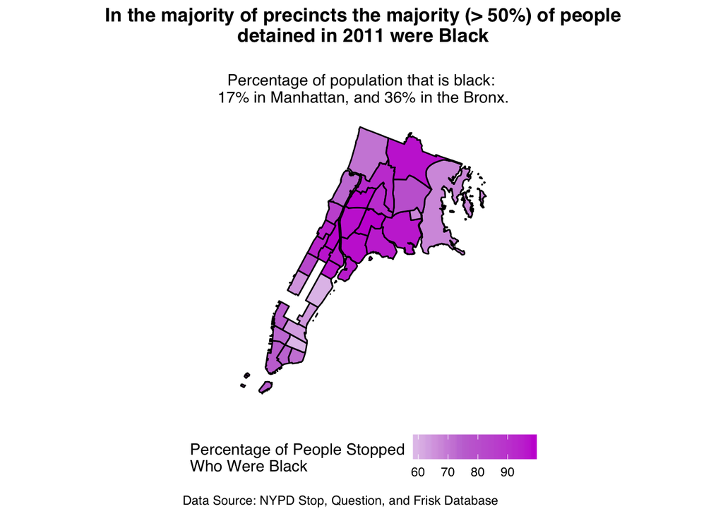

```r
manbronx <- ggplot(data = pdfm) +
  geom_sf(color="black", aes(fill = percentage)) +
  scale_fill_gradient2(low="#EFEDF5", mid="#C576D5", high=ncm_highlight, midpoint=75, name="Percentage of People Stopped\nWho Were Black") +
  theme(panel.grid.major = element_line(colour = "white"), panel.grid.minor = element_blank(),
        plot.title = element_text(hjust = 0.5, face = "bold"), axis.text = element_blank(),
        plot.subtitle = element_text(hjust=0.5), panel.background = element_rect(fill = "white"),
        text=element_text(family=ncm_font), strip.background = element_rect(fill=ncm_contrast), strip.text = element_text(color="black"),
        axis.ticks =element_blank(), legend.position = "bottom") +
  labs(title="In the majority of precincts the majority (> 50%) of people\ndetained in 2011 were Black\n",
       subtitle = "Percentage of population that is black: \n17% in Manhattan, and 36% in the Bronx.",
       caption="Data Source: NYPD Stop, Question, and Frisk Database")

manbronx
```

```r
pct_race <- read.csv("pdfr.csv")
pdfr = merge(precincts,pct_race, by='precinct')
pdfr= pdfr[pdfr$race == 'B',]
manhattan_and_bronx <- c(1,5,6,7,9,10,13,14,15,16,17,19,20,22,23,24,25,26,28,30,32,33,34,40, 41, 42, 43, 44, 45, 46, 47, 48, 49, 50, 52)

pdfqbs= pdfr[!(pdfr$precinct %in% manhattan_and_bronx) ,]
```

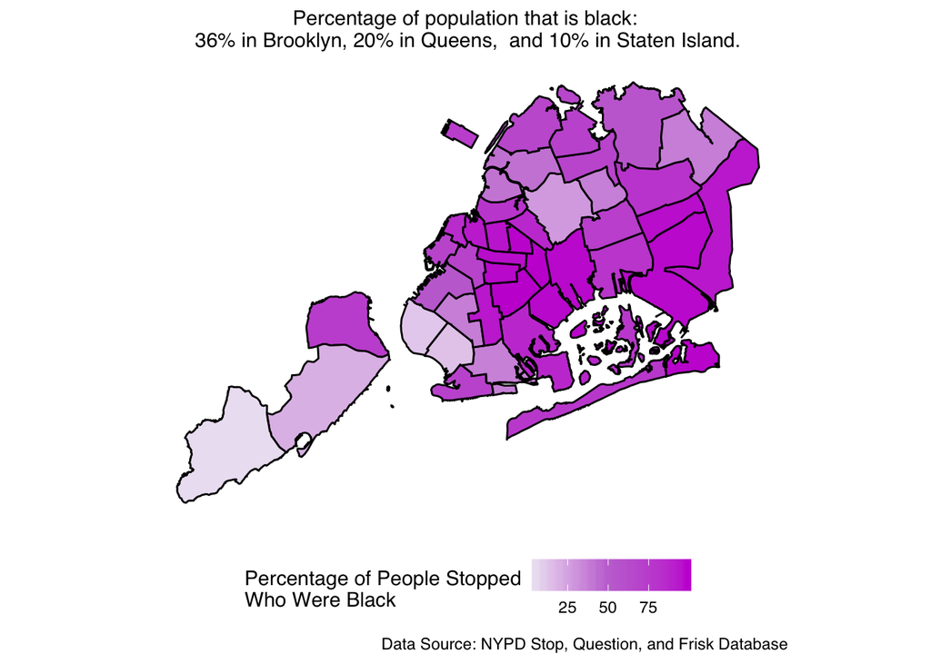

```r
ggplot(data = pdfqbs) +
  geom_sf(color="black", aes(fill = percentage)) + scale_fill_gradient2(low="#EFEDF5", mid="#C576D5", high=ncm_highlight, midpoint=50, name="Percentage of People Stopped\nWho Were Black") +
  theme(panel.grid.major = element_line(colour = "white"), panel.grid.minor = element_blank(),
        plot.title = element_text(hjust = 0.5, face = "bold"),
        plot.subtitle = element_text(hjust=0.5), panel.background = element_rect(fill = "white"),
        text=element_text(family=ncm_font), strip.background = element_rect(fill=ncm_contrast), strip.text = element_text(color="black"), axis.text = element_blank(),
        axis.ticks =element_blank(), legend.position = "bottom") +
  labs(subtitle = "Percentage of population that is black: \n36% in Brooklyn, 20% in Queens,  and 10% in Staten Island.",
       caption="Data Source: NYPD Stop, Question, and Frisk Database")
```

### Arrests by and Complaints made to the NYPD

As in any major city, crimes take place in NYC at almost all times of day or night. When a crime is reported the exact time, date, and location of the occurence is noted, along with other information. More crimes happen between about 3pm to 7pm in the evening, and around noon. The number of crimes is also higher in the springtime, from March to June, than at other times of the year.

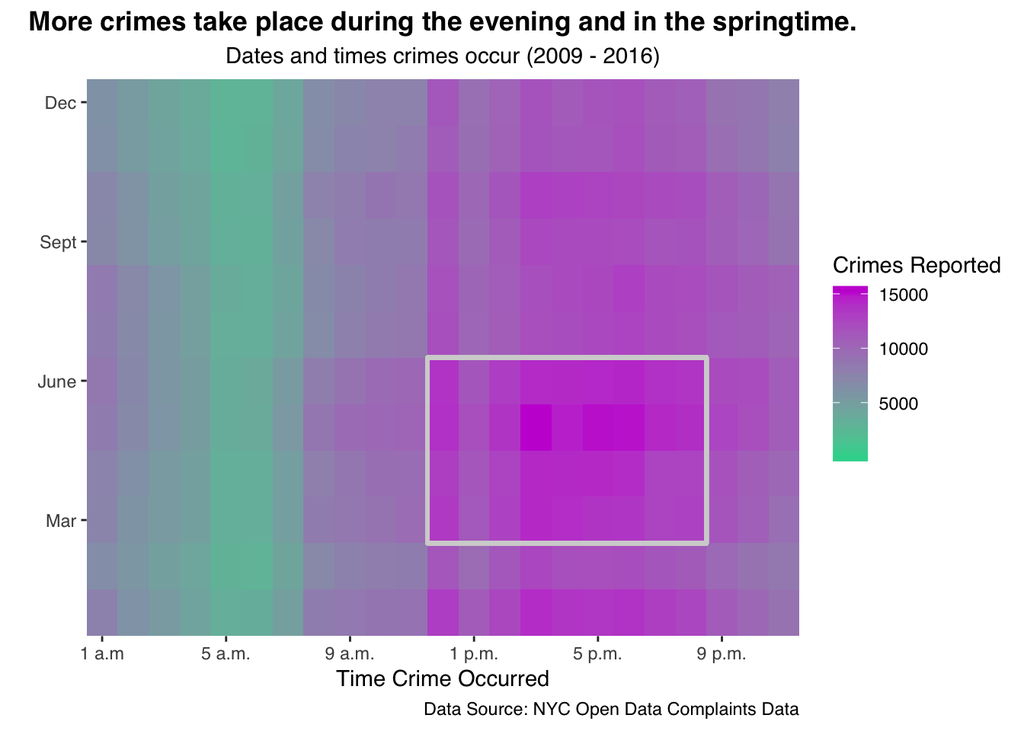

```r
p <- ggplot(ct, aes(Hour, Month))
p + geom_tile(aes(fill = Crimes.Called.In)) +
  scale_fill_gradient(low="#32D59B", high=ncm_highlight, name="Crimes Reported") +
  xlab("Time Crime Occurred") + ylab("") +
  scale_y_continuous(breaks=c(3,6,9,12), expand=c(0,0),
      labels=c("Mar","June","Sept","Dec")) +
  scale_x_continuous(breaks=c(1,5,9,13,17,21), expand=c(0,0),
      labels=c("1 a.m", "5 a.m.", "9 a.m.", "1 p.m.", "5 p.m.", "9 p.m.")) +
  labs(title="More crimes take place during the evening and in the springtime.",
       subtitle="Dates and times crimes occur (2009 - 2016)",
      caption="Data Source: NYC Open Data Complaints Data")  +
  theme(panel.background = element_blank(), plot.title = element_text(hjust = 0.5, face='bold'),
        plot.subtitle = element_text(hjust=0.5), text=element_text(family=ncm_font)) +
  geom_rect(xmin = 11.5, xmax = 20.5, ymin = 2.5, ymax = 6.5, fill=NA, size = 1, color="lightgrey", alpha = .2)
```

The next topic I was interested in was which crimes were the most common in NYC. A question that quickly came up was how to measure that - by the number of complaints or the number of actual arrests. This discrepancy varies greatly from crime to crime. Charges of “harassment 2” make up almost 15% of reported crimes to the NYPD but there are very few arrests for that offense. In contrast “dangerous drugs” account for about 5% of complaints called in but 18% of arrests.

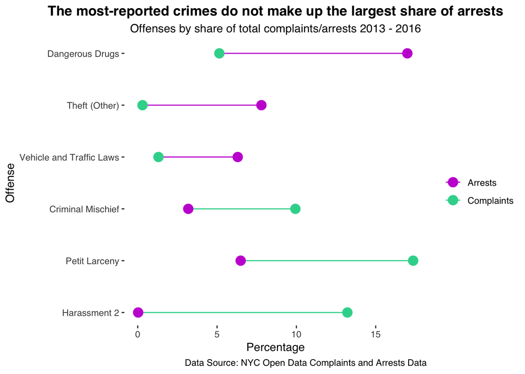

```r
ggplot(acd, aes(x=Percentage, y=rank, color=type)) +
   geom_line(aes(group = rank, color=c("#C732D5", "#C732D5", "#C732D5", "#C732D5",
  "#C732D5","#C732D5", "#32D59B", "#32D59B","#32D59B", "#32D59B","#32D59B","#32D59B"))) +
  geom_point(alpha=1, size=4) +
  scale_color_manual(values=c("#C732D5", "#32D59B", "#C732D5", "#32D59B"),
                     name="",
                        breaks=c('arrest', 'complaint'),
                        labels=c("Arrests", "Complaints")) +
   theme(panel.grid.major = element_blank(), panel.grid.minor = element_blank(),
        plot.title = element_text(hjust = 0.5, face = "bold"),
        plot.subtitle = element_text(hjust=0.5), panel.background = element_rect(fill = "white"),
         text=element_text(family=ncm_font), legend.key=element_blank()) +
  scale_y_continuous(breaks=c(1,2,3,4,5,6), labels=c("Harassment 2", "Petit Larceny", "Criminal Mischief", "Vehicle and Traffic Laws", "Theft (Other)", "Dangerous Drugs")) +
  scale_x_continuous(breaks=seq(0,25,5)) + ylab("Offense") +
  labs(title="The most-reported crimes do not make up the largest share of arrests",
              subtitle="Offenses by share of total complaints/arrests 2013 - 2016",
       caption="Data Source: NYC Open Data Complaints and Arrests Data")
```

Each borough has a very different population, ranging from ~450k in Staten Island to 2.5 million residents in Brooklyn. These sizes makes them comparable to other small cities in their own right. In fact, Brookyln alone has a similar population to Chicago, the third largest city by population in the United States. It is therefore important to look at crime numbers in the context of where they happened. The number of arrests overall has been falling over the past 5 years. When looked at on a per capita basis, Manhattan and the Bronx have the most arrests per one hundred thousand residents.

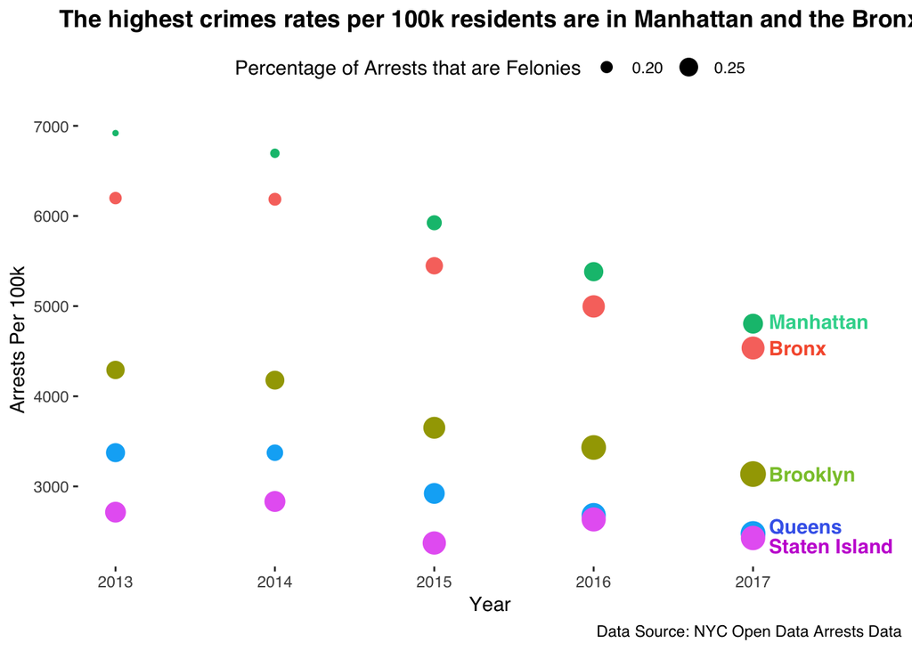

```r
ggplot(ybc, aes(x=YR, y=ARRESTS_PER_100K, color=Borough, size=PERC_FELONIES)) +
  geom_point(alpha=1)  +
  scale_fill_manual(values=ncm_colors[0:5]) +
  scale_size_continuous(name="Percentage of Arrests that are Felonies",
                        breaks=c(0.20, 0.25)) +
  scale_color_discrete(guide=FALSE) +
  ylab("Arrests Per 100k") +xlab("Year") +
  scale_x_continuous(breaks=seq(2013,2017,1))  +
  theme(panel.grid.major = element_blank(), panel.grid.minor = element_blank(),
        plot.title = element_text(hjust = 0.5, face = "bold"),
        plot.subtitle = element_text(hjust=0.5), panel.background = element_rect(fill = "white"),
        text=element_text(family=ncm_font), legend.position = "top", legend.key=element_blank()) +
   labs(title="The highest crimes rates per 100k residents are in Manhattan and the Bronx",
        caption="Data Source: NYC Open Data Arrests Data") +
  expand_limits(x = c(2013, 2017.7)) +
   annotate("text", x = 2017.1, y = 2340, label = "Staten Island",  hjust=0, family=ncm_font, fontface=2, color="#C732D5") +
annotate("text", x = 2017.1, y = 2560, label = "Queens",  hjust=0, family=ncm_font, fontface=2, color="#4369EB") +
annotate("text", x = 2017.1, y = 4830, label = "Manhattan",  hjust=0, family=ncm_font, fontface=2, color="#32D59B") +
annotate("text", x = 2017.1, y = 4540, label = "Bronx", hjust=0, family=ncm_font, fontface=2, color="#F65D3A") +
annotate("text", x = 2017.1, y = 3140, label = "Brooklyn",  hjust=0, family=ncm_font, fontface=2, color="#8AC437") + coord_cartesian(clip="off")
```

Across all non-residential locations the most common crimes are larceny and harassment. The prevalence of the crime differes from location to location. As expected the majority of crimes in department and chain stores are petit larceny (theft valued at <$1000). However at the ubituqitous bodegas the types of crimes committed are more varied.

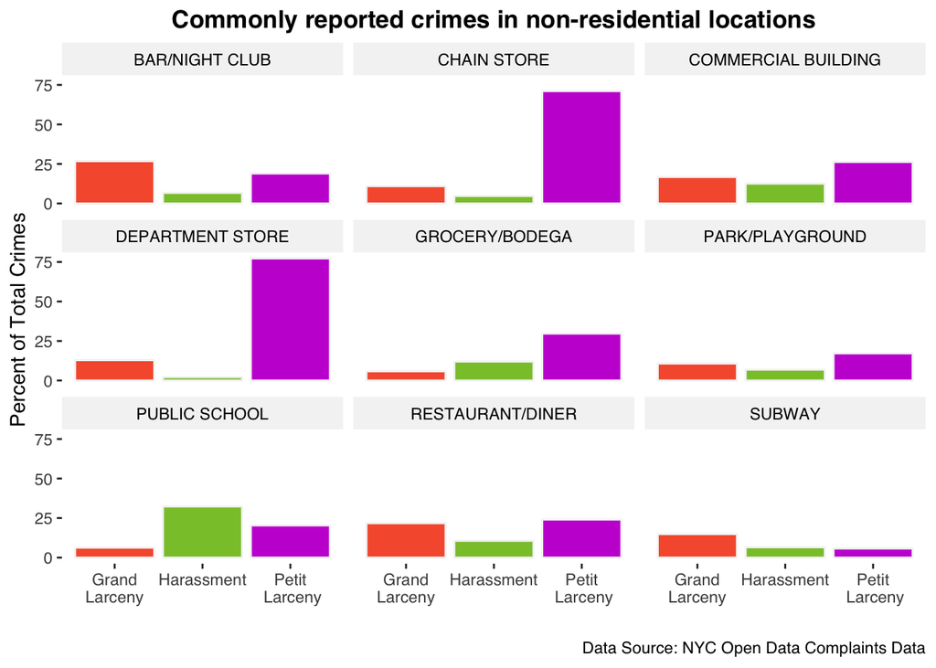

```r
p <- ggplot(data = g7, aes(x = OFNS_DESC, y = percentage))  +
     facet_wrap(~PREM_TYP_DESC) + geom_bar(stat = "identity", color = ncm_contrast, aes(fill=OFNS_DESC)) +
  scale_x_discrete(labels=c("Grand\nLarceny", "Harassment", "Petit\n Larceny")) +xlab("") +
  scale_fill_manual(values=ncm_colors[3:0]) +
  scale_y_continuous(breaks=seq(0, 100, 25)) +
 theme(panel.grid.major = element_blank(), panel.grid.minor = element_blank(),
        plot.title = element_text(hjust = 0.5, face = "bold"),
        plot.subtitle = element_text(hjust=0.5), panel.background = element_rect(fill = "white"),
        legend.position="none", text=element_text(family=ncm_font), strip.background = element_rect(fill=ncm_contrast), strip.text = element_text(color="black")) +
  labs(title="Commonly reported crimes in non-residential locations",
        caption="Data Source: NYC Open Data Complaints Data") +ylab("Percent of Total Crimes")

p
```